# HW3

Author

Sabrina (Hsi-Hsuan) Yang

```r
library(forcats)
library(tidytext)
library(readr)
library(dplyr)
library(ggplot2)
library(tidyr)
```

Question 1

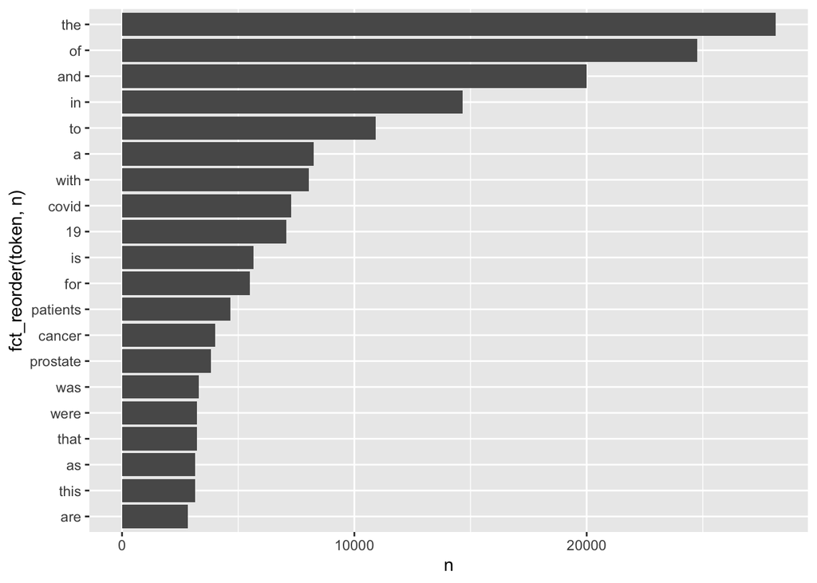

```r
pubmed <- read_csv ("https://raw.githubusercontent.com/USCbiostats/data-science-data/master/03_pubmed/pubmed.csv")
pubmed %>%
  unnest_tokens(token, abstract) %>%
  count(token)%>%
  top_n(20, n)%>%
  ggplot(aes(n, fct_reorder(token,n)))+
  geom_col()
```

Top 7 words (the, of, and, in, to, a, with) are stop words; therefore, we should remove them

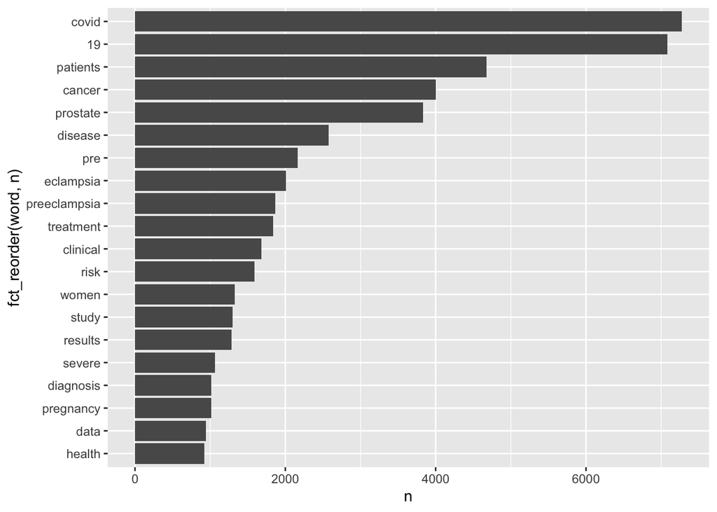

```r
#Removing the stop words
pubmed %>%
  unnest_tokens(word, abstract) %>%
  anti_join(tidytext::stop_words)%>%
  count(word, sort=T)%>%
  top_n(20,n)%>%
  ggplot(aes(n, fct_reorder(word, n)))+
  geom_col()
```

The top 1 word is “covid”, followed by the number “19”, “patients” and “cancer” after removing stop words.

```r
#The 5 most common tokens for each search term after removing stop words
pubmed %>%
  unnest_tokens(word, abstract) %>%
  anti_join(tidytext::stop_words) %>%
  group_by(term) %>%
  count(word) %>%
  top_n(5,n)
```

```
# A tibble: 25 × 3
# Groups:   term [5]
   term            word         n
   <chr>           <chr>    <int>
 1 covid           19        7035
 2 covid           covid     7275
 3 covid           disease    943
 4 covid           pandemic   800
 5 covid           patients  2293
 6 cystic fibrosis cf         625
 7 cystic fibrosis cystic     862
 8 cystic fibrosis disease    400
 9 cystic fibrosis fibrosis   867
10 cystic fibrosis patients   586
# ℹ 15 more rows
```

Question 2

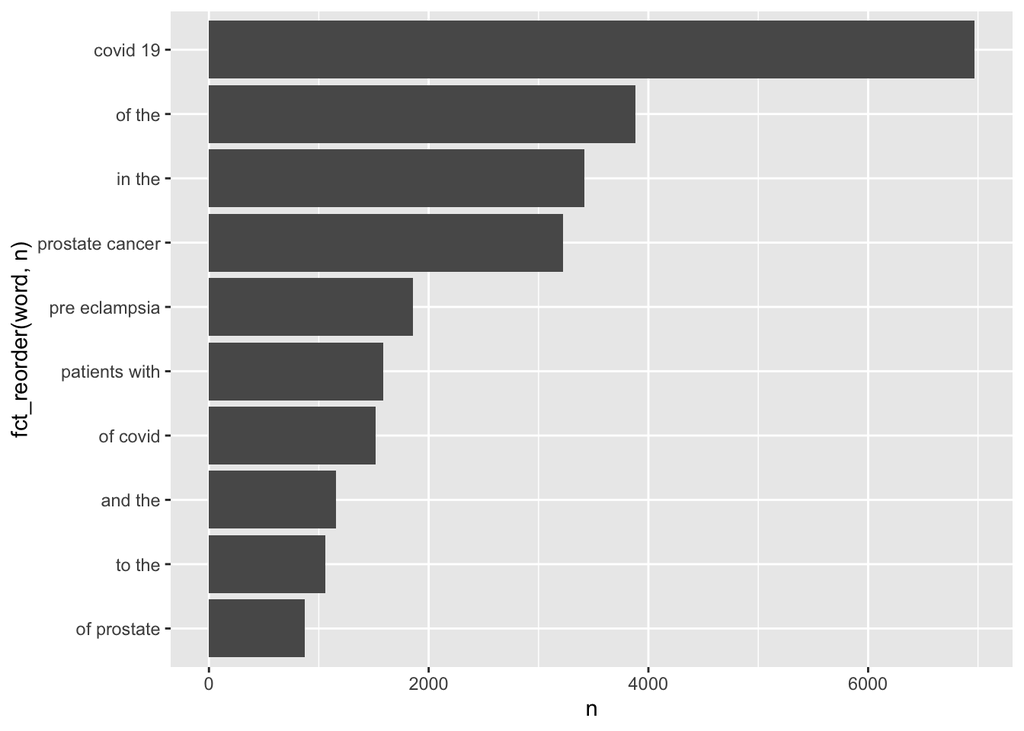

```r
pubmed %>%
   unnest_ngrams(word, abstract, n = 2) %>%
 count(word, sort = T) %>%
 top_n(10,n) %>%
 ggplot(aes(n, fct_reorder(word, n)))+
 geom_col()
```

The second and third words are consist of all stop words, so it is better to remove them.

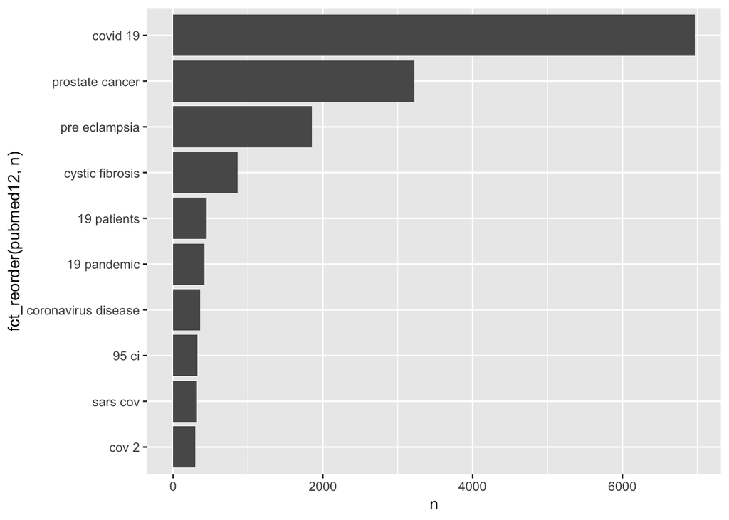

```r
#Removing stop words
pubmed_2 <- pubmed %>%
  unnest_ngrams(word, abstract ,n=2) %>%
  separate (word, c("word1", "word2"),sep = " ") %>%
  anti_join(
    tidytext::stop_words, by =c("word1" = "word")
  ) %>%
  anti_join(
    tidytext::stop_words, by =c("word2" = "word")
  ) %>%

  unite(pubmed12, word1, word2, sep= " ")
pubmed_2 %>%
count(pubmed12, sort = T) %>%
 top_n(10,n) %>%
 ggplot(aes(n, fct_reorder(pubmed12, n)))+
 geom_col()
```

Top 3 bigrams are “covid 19”, “prostate cancer”, “pre eclampsia.”

Question 3

```r
pubmed_3 <- pubmed %>%
  unnest_tokens(abstract, abstract) %>%
  filter(!(abstract %in% stop_words$word)) %>%
  count(abstract, term) %>%
  group_by(term)%>%
  bind_tf_idf(abstract, term, n) %>%
  top_n(5, n) %>%
  arrange(desc(tf_idf))
pubmed_3 %>%
  group_by(term) %>%
  arrange(desc(tf_idf))
```

```
# A tibble: 25 × 6
# Groups:   term [5]
   abstract     term                n      tf   idf tf_idf
   <chr>        <chr>           <int>   <dbl> <dbl>  <dbl>
 1 covid        covid            7275 0.0647  1.61  0.104
 2 prostate     prostate cancer  3832 0.0563  1.61  0.0906
 3 eclampsia    preeclampsia     2005 0.0255  1.61  0.0411
 4 preeclampsia preeclampsia     1863 0.0237  1.61  0.0382
 5 meningitis   meningitis        429 0.0164  1.61  0.0264
 6 cf           cystic fibrosis   625 0.0234  0.916 0.0215
 7 fibrosis     cystic fibrosis   867 0.0325  0.511 0.0166
 8 cystic       cystic fibrosis   862 0.0323  0.511 0.0165
 9 meningeal    meningitis        219 0.00837 1.61  0.0135
10 pandemic     covid             800 0.00711 1.61  0.0114
# ℹ 15 more rows
```

Top 5 tokens for “covid”: covid, pandemic, 19, disease, patients. Top 5 tokens for “prostate cancer”: prostate, cancer, disease, patients, treatment. Top 5 tokens for “preeclampsia”: eclampsia, preeclampsia, pregnancy, pre, women. Top 5 tokens for “meningitis”: meningitis, meningeal, csf, clinical, patients. Top 5 tokens for “cystic fibrosis”: cf, fibrosis, cystic, disease, patients. The results for the top 5 tokens are the same to question 1. However, the way the results are showed is more meaningful than question 1 as more important information come first compared to question 1 where it is listed in alphabetical order.